# Step 4: Explore one-way sensitivity of predicted clearance

Author

NAMLink

# Purpose

This optional extension asks how three target-related parameters influence the **a priori predicted clearance**:

- target reference concentration;
- target-complex internalization rate (`kint`); and
- target degradation rate (`kdeg`).

Each parameter is changed one at a time to 0.1 or 10 times its a priori value. All other model inputs remain fixed. The completed simulation from Tutorial 2 is the 1-fold reference, so no redundant 1-fold sensitivity run is generated.

This is a local, one-way sensitivity analysis. It is not parameter fitting, a global sensitivity analysis, or a statement about uncertainty distributions.

## Prerequisites

Run Tutorials 1 and 2 first. This script needs the configuration workbooks, the PK-Sim/MoBi model files, and the simulation run recorded by Tutorial 2. Tutorial 3 is not required because this script calculates its reference clearance from the same saved simulation CSV files.

# 1. Set up portable paths and analysis choices

```r
find_project_root_bootstrap <- function(start = getwd()) {
  current <- normalizePath(start, winslash = "/", mustWork = TRUE)
  repeat {
    required <- file.path(
      current,
      c("00_Data", "01_Models", "02_APriori_PBPK_Workflow")
    )
    if (all(dir.exists(required))) return(current)
    parent <- dirname(current)
    if (identical(parent, current)) stop("Project root not found.")
    current <- parent
  }
}

PROJECT_ROOT <- find_project_root_bootstrap()
WORKFLOW_DIR <- file.path(PROJECT_ROOT, "02_APriori_PBPK_Workflow")
DATA_DIR <- file.path(PROJECT_ROOT, "00_Data")
CONFIG_DIR <- file.path(WORKFLOW_DIR, "Configurations")

# Tutorial-local functions. Keeping these definitions in this file makes
# the Quarto tutorial independently runnable without a separate R helper.
# The Quarto files source this file to keep the tutorial narrative readable.
# Functions here perform validation, path resolution, result import, and the
# noncompartmental calculations used in both the primary and sensitivity
# analyses. No function fits or calibrates the PBPK model to observed PK data.

find_project_root <- function(start = getwd()) {
  current <- normalizePath(start, winslash = "/", mustWork = TRUE)

  repeat {
    expected <- file.path(
      current,
      c("00_Data", "01_Models", "02_APriori_PBPK_Workflow")
    )
    if (all(dir.exists(expected))) return(current)

    parent <- dirname(current)
    if (identical(parent, current)) {
      stop(
        "Could not locate the project root. Start R from this project or one ",
        "of its subfolders. Expected 00_Data/, 01_Models/, and ",
        "02_APriori_PBPK_Workflow/ in the project root."
      )
    }
    current <- parent
  }
}

check_package_versions <- function(required) {
  installed <- vapply(
    names(required),
    requireNamespace,
    quietly = TRUE,
    FUN.VALUE = logical(1)
  )
  if (any(!installed)) {
    stop(
      "Install the following R package(s) before continuing: ",
      paste(names(required)[!installed], collapse = ", ")
    )
  }

  versions <- vapply(
    names(required),
    function(package) as.character(utils::packageVersion(package)),
    FUN.VALUE = character(1)
  )
  too_old <- vapply(
    names(required),
    function(package) {
      utils::compareVersion(versions[[package]], required[[package]]) < 0
    },
    FUN.VALUE = logical(1)
  )
  if (any(too_old)) {
    details <- paste0(
      names(required)[too_old], " >= ", required[too_old],
      " (installed: ", versions[too_old], ")"
    )
    stop("Package version requirement not met: ", paste(details, collapse = "; "))
  }

  data.frame(
    Package = names(versions),
    Installed = unname(versions),
    Minimum = unname(required),
    row.names = NULL,
    check.names = FALSE
  )
}

assert_files_exist <- function(paths, description = "Required input") {
  missing <- paths[!file.exists(paths)]
  if (length(missing) > 0) {
    stop(
      description, " file(s) not found:\n- ",
      paste(normalizePath(missing, winslash = "/", mustWork = FALSE),
            collapse = "\n- ")
    )
  }
  invisible(paths)
}

normalize_species <- function(x) {
  x_clean <- tolower(trimws(as.character(x)))
  dplyr::case_when(
    x_clean == "human" ~ "Human",
    x_clean %in% c("nhp", "monkey", "primate", "cynomolgus monkey") ~
      "Monkey",
    TRUE ~ stringr::str_to_title(as.character(x))
  )
}

time_to_hours <- function(time, unit) {
  unit_clean <- tolower(trimws(as.character(unit)))
  dplyr::case_when(
    unit_clean %in% c("h", "hr", "hrs", "hour", "hours") ~
      as.numeric(time),
    unit_clean %in% c("d", "day", "days") ~ as.numeric(time) * 24,
    unit_clean %in% c("min", "mins", "minute", "minutes") ~
      as.numeric(time) / 60,
    TRUE ~ NA_real_
  )
}

normalize_micro_unit <- function(x) {
  micro_symbols <- paste0(intToUtf8(181), intToUtf8(956))
  x <- as.character(x)
  Encoding(x) <- "UTF-8"
  tolower(chartr(micro_symbols, "uu", x))
}

parse_scenario_name <- function(x) {
  base <- tools::file_path_sans_ext(basename(x))
  base <- sub("_mpk$", "", base)
  parts <- strsplit(base, "_", fixed = TRUE)[[1]]
  n_parts <- length(parts)
  if (n_parts < 3L) stop("Could not parse scenario name: ", x)

  molecule <- paste(parts[seq_len(n_parts - 2L)], collapse = "_")
  species <- normalize_species(parts[n_parts - 1L])
  dose <- suppressWarnings(as.numeric(parts[n_parts]))
  if (!is.finite(dose)) stop("Dose is not numeric in scenario name: ", x)

  list(Molecule = molecule, Species = species, Dose = dose)
}

read_parameter_source <- function(path) {
  assert_files_exist(path, "Parameter source")
  x <- openxlsx::read.xlsx(path, sheet = 1, check.names = FALSE)
  if (ncol(x) < 7L) {
    stop("Expected at least seven columns in ", path)
  }
  names(x)[seq_len(7)] <- c(
    "Drug.Name", "Target.Name", "Parameter.Name", "Value", "Unit",
    "Source", "Method"
  )

  x |>
    dplyr::transmute(
      Drug.Name = trimws(as.character(.data$Drug.Name)),
      Target.Name = trimws(as.character(.data$Target.Name)),
      Parameter.Name = trimws(as.character(.data$Parameter.Name)),
      Value = as.numeric(.data$Value),
      Unit = trimws(as.character(.data$Unit)),
      Source = as.character(.data$Source),
      Method = as.character(.data$Method)
    ) |>
    dplyr::filter(.data$Drug.Name != "", .data$Parameter.Name != "")
}

read_target_lookup <- function(parameter_files) {
  purrr::map_dfr(parameter_files, read_parameter_source) |>
    dplyr::distinct(.data$Drug.Name, .data$Target.Name) |>
    dplyr::transmute(
      Molecule = .data$Drug.Name,
      Target = .data$Target.Name
    ) |>
    dplyr::distinct(.data$Molecule, .keep_all = TRUE)
}

read_molecular_weight_lookup <- function(data_files) {
  purrr::map_dfr(data_files, function(path) {
    assert_files_exist(path, "Observed data")
    utils::read.csv(
      path,
      stringsAsFactors = FALSE,
      check.names = FALSE,
      fileEncoding = "UTF-8-BOM"
    ) |>
      dplyr::transmute(
        Molecule = trimws(as.character(.data$Molecule)),
        MW_g_mol = as.numeric(.data$Molecular.Weight)
      )
  }) |>
    dplyr::filter(is.finite(.data$MW_g_mol)) |>
    dplyr::distinct(.data$Molecule, .keep_all = TRUE)
}
```

```r
resolve_simulation_results <- function(workflow_dir, allow_latest_fallback = TRUE) {
  results_root <- file.path(workflow_dir, "SimsOutputs", "SimulationResults")
  manifest <- file.path(workflow_dir, "SimsOutputs", "latest_simulation_run.txt")

  if (file.exists(manifest)) {
    run_name <- trimws(readLines(manifest, warn = FALSE, n = 1L))
    selected <- file.path(results_root, run_name)
    if (nzchar(run_name) && dir.exists(selected)) {
      return(normalizePath(selected, winslash = "/", mustWork = TRUE))
    }
    warning("The simulation manifest points to a missing folder: ", selected)
  }

  if (!allow_latest_fallback) {
    stop(
      "No valid simulation manifest was found. Run 02_Run_Sims.qmd before ",
      "processing results."
    )
  }

  folders <- list.dirs(results_root, recursive = FALSE, full.names = TRUE)
  if (length(folders) == 0L) {
    stop("No simulation result folders found in ", results_root)
  }
  selected <- folders[which.max(file.mtime(folders))]
  warning(
    "No valid run manifest was found; using the most recently modified ",
    "simulation folder: ", basename(selected)
  )
  normalizePath(selected, winslash = "/", mustWork = TRUE)
}

find_mab_concentration_column <- function(column_names) {
  candidates <- grep(
    "PeripheralVenousBlood.*Plasma.*\\[",
    column_names,
    value = TRUE
  )
  candidates <- candidates[grepl("\\|mAb\\|", candidates)]
  if (length(candidates) != 1L) {
    stop(
      "Expected exactly one peripheral venous plasma mAb concentration ",
      "column; found ", length(candidates), "."
    )
  }
  candidates
}

read_simulation_profile <- function(path, mw_lookup) {
  meta <- parse_scenario_name(path)
  raw <- data.table::fread(path, data.table = FALSE, check.names = FALSE)
  concentration_column <- find_mab_concentration_column(names(raw))
  concentration_unit <- sub(
    ".*\\[([^]]+)\\]$",
    "\\1",
    concentration_column
  )
  concentration_unit_normalized <- normalize_micro_unit(concentration_unit)
  if (!identical(concentration_unit_normalized, "umol/l")) {
    stop(
      "Expected simulated plasma concentration in micromol/L; found ",
      concentration_unit, " in ", basename(path), "."
    )
  }
  mw <- mw_lookup$MW_g_mol[mw_lookup$Molecule == meta$Molecule]
  if (length(mw) != 1L || !is.finite(mw)) {
    stop("No unique molecular weight found for ", meta$Molecule)
  }

  tibble::tibble(
    Molecule = meta$Molecule,
    Species = meta$Species,
    Dose = meta$Dose,
    IndividualId = as.character(raw[["IndividualId"]]),
    Time_h = as.numeric(raw[["Time [min]"]]) / 60,
    # micromol/L * g/mol / 1000 = microgram/mL.
    Conc_ug_mL = as.numeric(raw[[concentration_column]]) * mw / 1000
  )
}

mean_or_na <- function(x) {
  x <- x[is.finite(x)]
  if (length(x) == 0L) NA_real_ else mean(x)
}

prepare_profile <- function(time_h, conc, t_end_h = Inf) {
  profile <- tibble::tibble(
    Time_h = as.numeric(time_h),
    Conc = as.numeric(conc)
  ) |>
    dplyr::filter(
      is.finite(.data$Time_h), is.finite(.data$Conc),
      .data$Time_h >= 0, .data$Conc >= 0
    ) |>
    dplyr::group_by(.data$Time_h) |>
    dplyr::summarise(Conc = mean(.data$Conc), .groups = "drop") |>
    dplyr::arrange(.data$Time_h)

  if (nrow(profile) == 0L) return(profile)

  # If the requested boundary lies between observations, add a boundary value.
  if (is.finite(t_end_h) && min(profile$Time_h) < t_end_h &&
      max(profile$Time_h) > t_end_h && !any(profile$Time_h == t_end_h)) {
    lower <- max(which(profile$Time_h < t_end_h))
    upper <- min(which(profile$Time_h > t_end_h))
    fraction <- (t_end_h - profile$Time_h[lower]) /
      (profile$Time_h[upper] - profile$Time_h[lower])
    c1 <- profile$Conc[lower]
    c2 <- profile$Conc[upper]
    boundary_conc <- if (c1 > 0 && c2 > 0) {
      exp(log(c1) + fraction * (log(c2) - log(c1)))
    } else {
      c1 + fraction * (c2 - c1)
    }
    profile <- dplyr::bind_rows(
      profile,
      tibble::tibble(Time_h = t_end_h, Conc = boundary_conc)
    ) |>
      dplyr::arrange(.data$Time_h)
  }

  profile <- dplyr::filter(profile, .data$Time_h <= t_end_h)
  if (nrow(profile) > 0L && !any(profile$Time_h == 0)) {
    profile <- dplyr::bind_rows(
      tibble::tibble(Time_h = 0, Conc = 0),
      profile
    )
  }
  profile
}

linear_up_log_down_auc <- function(profile) {
  if (nrow(profile) < 2L) return(NA_real_)
  dt <- diff(profile$Time_h)
  c1 <- profile$Conc[-nrow(profile)]
  c2 <- profile$Conc[-1L]
  log_down <- c2 < c1 & c1 > 0 & c2 > 0
  intervals <- ifelse(
    log_down,
    dt * (c1 - c2) / log(c1 / c2),
    dt * (c1 + c2) / 2
  )
  sum(intervals)
}

best_terminal_fit <- function(profile, min_points = 3L) {
  positive <- profile |>
    dplyr::filter(.data$Conc > 0) |>
    dplyr::arrange(.data$Time_h)
  if (nrow(positive) < min_points) {
    return(tibble::tibble(
      Lambda_z_1_h = NA_real_,
      Terminal_points_n = NA_integer_,
      Adjusted_R_squared = NA_real_
    ))
  }

  cmax_index <- which.max(positive$Conc)[1]
  post_cmax <- if (cmax_index < nrow(positive)) {
    positive[(cmax_index + 1L):nrow(positive), , drop = FALSE]
  } else {
    positive[0, , drop = FALSE]
  }
  if (nrow(post_cmax) < min_points) {
    post_cmax <- positive[cmax_index:nrow(positive), , drop = FALSE]
  }
  if (nrow(post_cmax) < min_points) {
    return(tibble::tibble(
      Lambda_z_1_h = NA_real_,
      Terminal_points_n = NA_integer_,
      Adjusted_R_squared = NA_real_
    ))
  }

  x <- post_cmax$Time_h
  y <- log(post_cmax$Conc)
  total_n <- length(x)
  suffix_sum <- function(z) rev(cumsum(rev(z)))
  sx <- suffix_sum(x)
  sy <- suffix_sum(y)
  sxx <- suffix_sum(x * x)
  syy <- suffix_sum(y * y)
  sxy <- suffix_sum(x * y)

  terminal_n <- seq.int(min_points, total_n)
  start <- total_n - terminal_n + 1L
  centered_xx <- sxx[start] - sx[start]^2 / terminal_n
  centered_yy <- syy[start] - sy[start]^2 / terminal_n
  centered_xy <- sxy[start] - sx[start] * sy[start] / terminal_n
  slope <- centered_xy / centered_xx
  r_squared <- (centered_xy^2) / (centered_xx * centered_yy)
  r_squared <- pmin(pmax(r_squared, 0), 1)
  adjusted_r_squared <-
    1 - (1 - r_squared) * (terminal_n - 1) / (terminal_n - 2)
```

```r
  candidates <- tibble::tibble(
    Lambda_z_1_h = -slope,
    Terminal_points_n = terminal_n,
    Adjusted_R_squared = adjusted_r_squared
  ) |>
    dplyr::filter(
      is.finite(.data$Lambda_z_1_h), .data$Lambda_z_1_h > 0,
      is.finite(.data$Adjusted_R_squared)
    ) |>
    dplyr::arrange(
      dplyr::desc(.data$Adjusted_R_squared),
      dplyr::desc(.data$Terminal_points_n)
    )

  if (nrow(candidates) == 0L) {
    tibble::tibble(
      Lambda_z_1_h = NA_real_,
      Terminal_points_n = NA_integer_,
      Adjusted_R_squared = NA_real_
    )
  } else {
    candidates[1, , drop = FALSE]
  }
}

profile_pk_metrics <- function(time_h, conc, dose_mg_kg, t_end_h = 28 * 24) {
  profile <- prepare_profile(time_h, conc, t_end_h = t_end_h)
  if (nrow(profile) < 2L || !any(profile$Conc > 0)) {
    return(tibble::tibble(
      Cmax_ug_mL = NA_real_, AUC0_28d_ug_h_mL = NA_real_,
      AUClast_ug_h_mL = NA_real_, AUCinf_ug_h_mL = NA_real_,
      AUC_extrapolated_pct = NA_real_, Lambda_z_1_h = NA_real_,
      Terminal_half_life_day = NA_real_, Terminal_points_n = NA_integer_,
      Last_time_h = NA_real_, CL_L_day_kg = NA_real_
    ))
  }

  terminal <- best_terminal_fit(profile)
  auc_last <- linear_up_log_down_auc(profile)
  positive <- dplyr::filter(profile, .data$Conc > 0)
  last <- positive[nrow(positive), , drop = FALSE]
  lambda_z <- terminal$Lambda_z_1_h[[1]]
  extrapolated_auc <- if (is.finite(lambda_z)) last$Conc[[1]] / lambda_z else NA_real_
  auc_inf <- if (is.finite(extrapolated_auc)) auc_last + extrapolated_auc else NA_real_

  tibble::tibble(
    Cmax_ug_mL = max(profile$Conc, na.rm = TRUE),
    # When observations end before day 28, this is the available partial AUC.
    AUC0_28d_ug_h_mL = auc_last,
    AUClast_ug_h_mL = auc_last,
    AUCinf_ug_h_mL = auc_inf,
    AUC_extrapolated_pct = if (is.finite(auc_inf) && auc_inf > 0) {
      100 * extrapolated_auc / auc_inf
    } else {
      NA_real_
    },
    Lambda_z_1_h = lambda_z,
    Terminal_half_life_day = if (is.finite(lambda_z)) {
      log(2) / lambda_z / 24
    } else {
      NA_real_
    },
    Terminal_points_n = terminal$Terminal_points_n[[1]],
    Last_time_h = last$Time_h[[1]],
    # Dose is mg/kg and AUC is mg*h/L, so dose/AUC is L/h/kg.
    CL_L_day_kg = if (is.finite(auc_inf) && auc_inf > 0) {
      24 * as.numeric(dose_mg_kg) / auc_inf
    } else {
      NA_real_
    }
  )
}

within_two_fold <- function(fold_error) {
  is.finite(fold_error) & fold_error >= 0.5 & fold_error <= 2
}

required_versions <- c(
  esqlabsR = "5.6.0", ospsuite = "12.4.2", dplyr = "1.1.0",
  tidyr = "1.3.0", purrr = "1.0.0", tibble = "3.2.0",
  ggplot2 = "3.4.0", scales = "1.2.0", data.table = "1.14.0",
  openxlsx = "4.2.5", knitr = "1.40"
)
package_versions <- check_package_versions(required_versions)

library(dplyr)
library(tidyr)
library(purrr)
library(tibble)
library(ggplot2)
library(scales)
library(data.table)
library(openxlsx)
library(knitr)

AUC_END_H <- 28 * 24
SA_FACTORS <- c(0.1, 10)
SA_PARAMETER_PATHS <- c(
  "Target reference concentration" = "Target|Reference concentration",
  "kint" = "Complex Internalization|kint",
  "kdeg" = "Target degradation|kdeg"
)
MAB_PLASMA_OUTPUT_PATH <-
  "Organism|PeripheralVenousBlood|mAb|Plasma (Peripheral Venous Blood)"

package_versions |>
  knitr::kable(caption = "R packages used for the sensitivity analysis")
```

R packages used for the sensitivity analysis

| Package | Installed | Minimum |
| --- | --- | --- |
| esqlabsR | 5.7.0 | 5.6.0 |
| ospsuite | 12.4.3 | 12.4.2 |
| dplyr | 1.2.1 | 1.1.0 |
| tidyr | 1.3.2 | 1.3.0 |
| purrr | 1.2.2 | 1.0.0 |
| tibble | 3.3.1 | 3.2.0 |
| ggplot2 | 4.0.3 | 3.4.0 |
| scales | 1.4.0 | 1.2.0 |
| data.table | 1.18.4 | 1.14.0 |
| openxlsx | 4.2.9 | 4.2.5 |
| knitr | 1.51 | 1.40 |

The model path strings above must match the quantities in the exported MoBi models. The script stops if a path is missing or matches more than one parameter; it does not guess a replacement.

# 2. Read scenario metadata and supporting lookups

```r
scenario_file <- file.path(CONFIG_DIR, "Scenarios.xlsx")
project_configuration_file <-
  file.path(WORKFLOW_DIR, "ProjectConfiguration.xlsx")
monkey_data_file <- file.path(DATA_DIR, "Monkey", "mAb_data_clean.csv")
human_data_file <- file.path(DATA_DIR, "Human", "mAb_data_human.csv")
parameter_files <- c(
  file.path(DATA_DIR, "Monkey", "Parameters.xlsx"),
  file.path(DATA_DIR, "Human", "Parameters_human.xlsx")
)

assert_files_exist(c(
  scenario_file, project_configuration_file, monkey_data_file,
  human_data_file, parameter_files
))

scenario_table <- openxlsx::read.xlsx(
  scenario_file,
  sheet = "Scenarios",
  check.names = FALSE
)

sa_scenarios <- scenario_table |>
  transmute(
    Scenario = as.character(.data$Scenario_name),
    Meta = map(.data$Scenario, parse_scenario_name),
    Molecule = map_chr(.data$Meta, "Molecule"),
    Species = map_chr(.data$Meta, "Species"),
    Dose_mg_kg = map_dbl(.data$Meta, "Dose")
  ) |>
  select(-.data$Meta) |>
  filter(.data$Species %in% c("Monkey", "Human"))

target_lookup <- read_target_lookup(parameter_files)
mw_lookup <- read_molecular_weight_lookup(
  c(monkey_data_file, human_data_file)
)

sa_scenarios <- sa_scenarios |>
  left_join(target_lookup, by = "Molecule") |>
  arrange(.data$Species, .data$Target, .data$Molecule, .data$Dose_mg_kg)

if (anyNA(sa_scenarios$Target)) {
  stop(
    "A target name is missing for: ",
    paste(sa_scenarios$Molecule[is.na(sa_scenarios$Target)], collapse = ", ")
  )
}

sa_scenarios |>
  count(.data$Species, name = "Scenarios") |>
  knitr::kable(caption = "Scenarios included in the sensitivity analysis")
```

Scenarios included in the sensitivity analysis

| Species | Scenarios |
| --- | --- |
| Human | 30 |
| Monkey | 14 |

# 3. Calculate the unvaried 1-fold clearance reference

The reference is obtained from the exact simulation folder selected by Tutorial 2. For each scenario, clearance is calculated from dose/AUCinf using the same linear-up/log-down and terminal-phase functions used in Tutorial 3. Because dose is expressed in mg/kg, clearance is reported in L/day/kg.

```r
results_folder <- resolve_simulation_results(
  WORKFLOW_DIR,
  allow_latest_fallback = TRUE
)
reference_files <- file.path(
  results_folder,
  paste0(sa_scenarios$Scenario, ".csv")
)
assert_files_exist(reference_files, "Unvaried scenario result")

read_reference_clearance <- function(path) {
  scenario_name <- tools::file_path_sans_ext(basename(path))
  scenario_meta <- sa_scenarios |>
    filter(.data$Scenario == scenario_name)
  if (nrow(scenario_meta) != 1L) {
    stop("No unique scenario metadata found for ", scenario_name)
  }

  profile <- read_simulation_profile(path, mw_lookup = mw_lookup)
  individual_metrics <- profile |>
    group_by(.data$IndividualId) |>
    group_modify(function(.x, .y) {
      profile_pk_metrics(
        .x$Time_h,
        .x$Conc_ug_mL,
        dose_mg_kg = scenario_meta$Dose_mg_kg[[1]],
        t_end_h = AUC_END_H
      )
    }) |>
    ungroup()

  tibble(
    Scenario = scenario_name,
    Molecule = scenario_meta$Molecule[[1]],
    Species = scenario_meta$Species[[1]],
    Dose_mg_kg = scenario_meta$Dose_mg_kg[[1]],
    Reference_CL_L_day_kg = mean_or_na(individual_metrics$CL_L_day_kg),
    Reference_individuals_n = nrow(individual_metrics)
  )
}

reference_clearance <- map_dfr(reference_files, read_reference_clearance)

if (any(!is.finite(reference_clearance$Reference_CL_L_day_kg))) {
  stop(
    "Reference clearance could not be calculated for: ",
    paste(
      reference_clearance$Scenario[
        !is.finite(reference_clearance$Reference_CL_L_day_kg)
      ],
      collapse = ", "
    )
  )
}

reference_clearance |>
  select(
    .data$Species, .data$Molecule, .data$Dose_mg_kg,
    .data$Reference_CL_L_day_kg, .data$Reference_individuals_n
  ) |>
  knitr::kable(
    digits = 4,
    caption = paste(
      "Unvaried clearance references from simulation run",
      basename(results_folder)
    )
  )
```

Unvaried clearance references from simulation run 2026-09-27 18-41

| Species | Molecule | Dose_mg_kg | Reference_CL_L_day_kg | Reference_individuals_n |
| --- | --- | --- | --- | --- |
| Human | Tocilizumab | 8.0 | 0.0099 | 1 |
| Human | Nivolumab | 1.0 | 0.0034 | 1 |
| Human | Nivolumab | 3.0 | 0.0034 | 1 |
| Human | Nivolumab | 4.0 | 0.0034 | 1 |
| Human | Nivolumab | 6.0 | 0.0034 | 1 |
| Human | Nivolumab | 10.0 | 0.0034 | 1 |
| Human | Nivolumab | 20.0 | 0.0034 | 1 |
| Human | Pembrolizumab | 2.0 | 0.0005 | 1 |
| Human | Pembrolizumab | 10.0 | 0.0005 | 1 |
| Human | Atezolizumab | 1.0 | 0.0022 | 1 |
| Human | Atezolizumab | 3.0 | 0.0022 | 1 |
| Human | Atezolizumab | 10.0 | 0.0022 | 1 |
| Human | Atezolizumab | 15.0 | 0.0022 | 1 |
| Human | Atezolizumab | 20.0 | 0.0022 | 1 |
| Human | Avelumab | 1.0 | 0.0034 | 1 |
| Human | Avelumab | 3.0 | 0.0033 | 1 |
| Human | Avelumab | 10.0 | 0.0034 | 1 |
| Human | Avelumab | 20.0 | 0.0034 | 1 |
| Human | Adalimumab | 0.5 | 0.0033 | 1 |
| Human | Adalimumab | 1.0 | 0.0033 | 1 |
| Human | Adalimumab | 3.0 | 0.0033 | 1 |
| Human | Adalimumab | 5.0 | 0.0033 | 1 |
| Human | Adalimumab | 10.0 | 0.0033 | 1 |
| Human | Golimumab | 0.1 | 0.0033 | 1 |
| Human | Golimumab | 0.3 | 0.0033 | 1 |
| Human | Golimumab | 1.0 | 0.0033 | 1 |
| Human | Golimumab | 3.0 | 0.0033 | 1 |
| Human | Golimumab | 6.0 | 0.0033 | 1 |
| Human | Golimumab | 10.0 | 0.0033 | 1 |
| Human | Bevacizumab | 15.0 | 0.0033 | 1 |
| Monkey | Tocilizumab | 10.0 | 0.0155 | 1 |
| Monkey | Nivolumab | 1.0 | 0.0107 | 1 |
| Monkey | Nivolumab | 10.0 | 0.0109 | 1 |
| Monkey | Pembrolizumab | 0.3 | 0.0019 | 1 |
| Monkey | Pembrolizumab | 3.0 | 0.0018 | 1 |
| Monkey | Pembrolizumab | 30.0 | 0.0019 | 1 |
| Monkey | Atezolizumab | 0.5 | 0.0084 | 1 |
| Monkey | Atezolizumab | 5.0 | 0.0074 | 1 |
| Monkey | Atezolizumab | 20.0 | 0.0075 | 1 |
| Monkey | Avelumab | 5.0 | 0.0109 | 1 |
| Monkey | Adalimumab | 3.0 | 0.0106 | 1 |
| Monkey | Golimumab | 3.0 | 0.0104 | 1 |
| Monkey | Bevacizumab | 4.0 | 0.0108 | 1 |
| Monkey | Bevacizumab | 5.0 | 0.0107 | 1 |

# 4. Run the 0.1-fold and 10-fold simulations

The function below creates six runs for each scenario: three parameters times two variation factors. Results remain in memory and are embedded in this HTML; they are not written to cache or companion table files.

```r
project_configuration <- esqlabsR::createProjectConfiguration(
  path = project_configuration_file,
  ignoreVersionCheck = TRUE
)

sa_run_options <- ospsuite::SimulationRunOptions$new()
sa_run_options$checkForNegativeValues <- FALSE
detected_cores <- parallel::detectCores(logical = FALSE)
if (!is.finite(detected_cores)) detected_cores <- 2L
sa_run_options$numberOfCores <- min(8L, max(1L, detected_cores - 1L))

run_sa_scenario <- function(
  scenario_name,
  molecule,
  species,
  dose_mg_kg
) {
  mw <- mw_lookup$MW_g_mol[mw_lookup$Molecule == molecule]
  if (length(mw) != 1L || !is.finite(mw)) {
    stop("No unique molecular weight found for ", molecule)
  }

  scenario_configuration <- esqlabsR::readScenarioConfigurationFromExcel(
    scenarioNames = scenario_name,
    projectConfiguration = project_configuration
  )
  scenario <- esqlabsR::createScenarios(
    scenarioConfigurations = scenario_configuration
  )[[scenario_name]]
  simulation <- scenario$simulation

  old_output_paths <- purrr::map_chr(
    simulation$outputSelections$allOutputs,
    "path"
  )
  ospsuite::clearOutputs(simulation = simulation)
  ospsuite::addOutputs(
    quantitiesOrPaths = MAB_PLASMA_OUTPUT_PATH,
    simulation = simulation
  )
  on.exit({
    ospsuite::clearOutputs(simulation = simulation)
    purrr::walk(
      old_output_paths,
      ~ ospsuite::addOutputs(
        quantitiesOrPaths = .x,
        simulation = simulation
      )
    )
    ospsuite::clearMemory()
  }, add = TRUE)

  parameter_paths <- unname(SA_PARAMETER_PATHS)
  initial_values <- setNames(
    map_dbl(parameter_paths, function(parameter_path) {
      values <- ospsuite::getQuantityValuesByPath(
        quantityPaths = parameter_path,
        simulation = simulation
      )
      if (length(values) != 1L || !is.finite(values)) {
        stop(
          "Expected one finite value for ", parameter_path,
          " in ", scenario_name
        )
      }
      as.numeric(values)
    }),
    parameter_paths
  )

  parameter_units <- setNames(
    map_chr(parameter_paths, function(parameter_path) {
      matched <- ospsuite::getAllParametersMatching(
        paths = parameter_path,
        container = simulation
      )
      if (length(matched) != 1L) {
        stop(
          "Expected one parameter match for ", parameter_path,
          " in ", scenario_name, "; found ", length(matched)
        )
      }
      as.character(matched[[1]]$unit)
    }),
    parameter_paths
  )

  is_formula <- map_lgl(
    parameter_paths,
    ~ ospsuite::isExplicitFormulaByPath(
      path = .x,
      simulation = simulation
    )
  )
  constant_paths <- parameter_paths[!is_formula]
  formula_paths <- parameter_paths[is_formula]

  result_ids <- setNames(
    map(
      parameter_paths,
      ~ setNames(vector("list", length(SA_FACTORS)), SA_FACTORS)
    ),
    parameter_paths
  )
  simulation_batches <- list()

  # Constant parameters can share one batch as long as every run supplies all
  # constant values and changes only the parameter under investigation.
  if (length(constant_paths) > 0L) {
    constant_batch <- ospsuite::createSimulationBatch(
      simulation = simulation,
      parametersOrPaths = constant_paths
    )
    for (parameter_path in constant_paths) {
      for (variation_factor in SA_FACTORS) {
        run_values <- initial_values[constant_paths]
        run_values[[parameter_path]] <-
          initial_values[[parameter_path]] * variation_factor
        result_ids[[parameter_path]][[as.character(variation_factor)]] <-
          constant_batch$addRunValues(parameterValues = run_values)
      }
    }
    simulation_batches <- c(simulation_batches, constant_batch)
  }

  # Formula parameters require separate batches so their expression can be
  # replaced by the requested scalar for that run.
  for (parameter_path in formula_paths) {
    formula_batch <- ospsuite::createSimulationBatch(
      simulation = simulation,
      parametersOrPaths = parameter_path
    )
    for (variation_factor in SA_FACTORS) {
      result_ids[[parameter_path]][[as.character(variation_factor)]] <-
        formula_batch$addRunValues(
          parameterValues =
            initial_values[[parameter_path]] * variation_factor
        )
    }
    simulation_batches <- c(simulation_batches, formula_batch)
  }

  batch_results <- ospsuite::runSimulationBatches(
    simulationBatches = simulation_batches,
    simulationRunOptions = sa_run_options,
    stopIfFails = FALSE
  )
  names(batch_results) <- NULL
  batch_results <- unlist(
    batch_results,
    recursive = FALSE,
    use.names = TRUE
  )

  result <- map_dfr(parameter_paths, function(parameter_path) {
    parameter_label <- names(SA_PARAMETER_PATHS)[
      match(parameter_path, SA_PARAMETER_PATHS)
    ]

    map_dfr(SA_FACTORS, function(variation_factor) {
      result_id <- result_ids[[parameter_path]][[
        as.character(variation_factor)
      ]]
      simulation_result <- purrr::pluck(batch_results, result_id)
      if (is.null(simulation_result)) {
        stop(
          "Sensitivity simulation failed for ", scenario_name, ": ",
          parameter_label, " at ", variation_factor, "-fold"
        )
      }

      output <- ospsuite::simulationResultsToDataFrame(
        simulation_result,
        quantitiesOrPaths = MAB_PLASMA_OUTPUT_PATH
      ) |>
        filter(.data$paths == MAB_PLASMA_OUTPUT_PATH)
      if (nrow(output) == 0L) {
        stop(
          "The requested plasma mAb output is missing for ", scenario_name,
          ": ", parameter_label, " at ", variation_factor, "-fold"
        )
      }

      concentration_units <- unique(
        normalize_micro_unit(output$unit)
      )
      if (!identical(concentration_units, "umol/l")) {
        stop(
          "Expected sensitivity output in micromol/L for ", scenario_name,
          "; found ", paste(unique(output$unit), collapse = ", "), "."
        )
      }

      metrics <- profile_pk_metrics(
        time_h = as.numeric(output$Time) / 60,
        conc = as.numeric(output$simulationValues) * mw / 1000,
        dose_mg_kg = dose_mg_kg,
        t_end_h = AUC_END_H
      )

      tibble(
        Scenario = scenario_name,
        Molecule = molecule,
        Species = species,
        Dose_mg_kg = dose_mg_kg,
        Parameter = parameter_label,
        Variation_factor = variation_factor,
        Parameter_value =
          initial_values[[parameter_path]] * variation_factor,
        Parameter_unit = parameter_units[[parameter_path]],
        Varied_CL_L_day_kg = metrics$CL_L_day_kg[[1]]
      )
    })
  }) |>
    arrange(.data$Parameter, .data$Variation_factor)

  expected_runs <- tidyr::crossing(
    Parameter = names(SA_PARAMETER_PATHS),
    Variation_factor = SA_FACTORS
  )
  missing_runs <- anti_join(
    expected_runs,
    result,
    by = c("Parameter", "Variation_factor")
  )
  if (nrow(missing_runs) > 0L ||
      any(!is.finite(result$Varied_CL_L_day_kg))) {
    stop(
      "Incomplete sensitivity results for ", scenario_name,
      ". Expected six finite runs."
    )
  }

  result
}

sa_results <- purrr::pmap_dfr(
  sa_scenarios |>
    select(
      scenario_name = .data$Scenario,
      molecule = .data$Molecule,
      species = .data$Species,
      dose_mg_kg = .data$Dose_mg_kg
    ),
  function(scenario_name, molecule, species, dose_mg_kg) {
    message("One-way sensitivity analysis: ", scenario_name)
    run_sa_scenario(scenario_name, molecule, species, dose_mg_kg)
  }
)
```

# 5. Express clearance changes relative to the reference

An index of 1 means that the parameter change produced no clearance change. The sign of (S) indicates the direction of the relationship.

```r
sa_change_table <- sa_results |>
  left_join(
    reference_clearance,
    by = c("Scenario", "Molecule", "Species", "Dose_mg_kg")
  ) |>
  left_join(target_lookup, by = "Molecule") |>
  mutate(
    CL_percent_delta =
      100 * (.data$Varied_CL_L_day_kg /
               .data$Reference_CL_L_day_kg - 1),
    Normalized_sensitivity_coefficient =
      log(.data$Varied_CL_L_day_kg /
            .data$Reference_CL_L_day_kg) /
      log(.data$Variation_factor),
    Normalized_sensitivity_index =
      1 + .data$Normalized_sensitivity_coefficient
  ) |>
  arrange(
    .data$Species, .data$Target, .data$Molecule, .data$Dose_mg_kg,
    .data$Parameter, .data$Variation_factor
  )

sa_mean_table <- sa_change_table |>
  group_by(
    .data$Species, .data$Target, .data$Molecule,
    .data$Parameter, .data$Variation_factor
  ) |>
  summarise(
    Mean_CL_percent_delta = mean_or_na(.data$CL_percent_delta),
    Mean_normalized_sensitivity_coefficient =
      mean_or_na(.data$Normalized_sensitivity_coefficient),
    Doses_averaged_n = sum(is.finite(.data$CL_percent_delta)),
    .groups = "drop"
  ) |>
  mutate(
    Mean_normalized_sensitivity_index =
      1 + .data$Mean_normalized_sensitivity_coefficient
  )

sa_change_table |>
  select(
    .data$Species, .data$Target, .data$Molecule, .data$Dose_mg_kg,
    .data$Parameter, .data$Variation_factor,
    .data$Reference_CL_L_day_kg, .data$Varied_CL_L_day_kg,
    .data$CL_percent_delta, .data$Normalized_sensitivity_index
  ) |>
  mutate(across(where(is.numeric), ~ round(.x, 4))) |>
  knitr::kable(
    caption = "Dose-level one-way sensitivity results",
    row.names = FALSE
  )
```

Dose-level one-way sensitivity results

| Species | Target | Molecule | Dose_mg_kg | Parameter | Variation_factor | Reference_CL_L_day_kg | Varied_CL_L_day_kg | CL_percent_delta | Normalized_sensitivity_index |
| --- | --- | --- | --- | --- | --- | --- | --- | --- | --- |
| Human | IL-6R | Tocilizumab | 8.0 | Target reference concentration | 0.1 | 0.0099 | 0.0042 | -57.3868 | 1.3705 |
| Human | IL-6R | Tocilizumab | 8.0 | Target reference concentration | 10.0 | 0.0099 | 0.0202 | 103.9975 | 1.3096 |
| Human | IL-6R | Tocilizumab | 8.0 | kdeg | 0.1 | 0.0099 | 0.0043 | -56.8104 | 1.3646 |
| Human | IL-6R | Tocilizumab | 8.0 | kdeg | 10.0 | 0.0099 | 0.0188 | 89.0732 | 1.2766 |
| Human | IL-6R | Tocilizumab | 8.0 | kint | 0.1 | 0.0099 | 0.0091 | -8.2655 | 1.0375 |
| Human | IL-6R | Tocilizumab | 8.0 | kint | 10.0 | 0.0099 | 0.0101 | 1.3167 | 1.0057 |
| Human | PD-1 | Nivolumab | 1.0 | Target reference concentration | 0.1 | 0.0034 | 0.0034 | 0.0001 | 1.0000 |
| Human | PD-1 | Nivolumab | 1.0 | Target reference concentration | 10.0 | 0.0034 | 0.0034 | 0.0001 | 1.0000 |
| Human | PD-1 | Nivolumab | 1.0 | kdeg | 0.1 | 0.0034 | 0.0034 | 0.0001 | 1.0000 |
| Human | PD-1 | Nivolumab | 1.0 | kdeg | 10.0 | 0.0034 | 0.0034 | 0.0001 | 1.0000 |
| Human | PD-1 | Nivolumab | 1.0 | kint | 0.1 | 0.0034 | 0.0034 | 0.0001 | 1.0000 |
| Human | PD-1 | Nivolumab | 1.0 | kint | 10.0 | 0.0034 | 0.0034 | 0.0001 | 1.0000 |
| Human | PD-1 | Nivolumab | 3.0 | Target reference concentration | 0.1 | 0.0034 | 0.0034 | 0.0000 | 1.0000 |
| Human | PD-1 | Nivolumab | 3.0 | Target reference concentration | 10.0 | 0.0034 | 0.0034 | 0.0000 | 1.0000 |
| Human | PD-1 | Nivolumab | 3.0 | kdeg | 0.1 | 0.0034 | 0.0034 | 0.0000 | 1.0000 |
| Human | PD-1 | Nivolumab | 3.0 | kdeg | 10.0 | 0.0034 | 0.0034 | 0.0000 | 1.0000 |
| Human | PD-1 | Nivolumab | 3.0 | kint | 0.1 | 0.0034 | 0.0034 | 0.0000 | 1.0000 |
| Human | PD-1 | Nivolumab | 3.0 | kint | 10.0 | 0.0034 | 0.0034 | 0.0000 | 1.0000 |
| Human | PD-1 | Nivolumab | 4.0 | Target reference concentration | 0.1 | 0.0034 | 0.0034 | -0.0002 | 1.0000 |
| Human | PD-1 | Nivolumab | 4.0 | Target reference concentration | 10.0 | 0.0034 | 0.0034 | -0.0002 | 1.0000 |
| Human | PD-1 | Nivolumab | 4.0 | kdeg | 0.1 | 0.0034 | 0.0034 | -0.0002 | 1.0000 |
| Human | PD-1 | Nivolumab | 4.0 | kdeg | 10.0 | 0.0034 | 0.0034 | -0.0002 | 1.0000 |
| Human | PD-1 | Nivolumab | 4.0 | kint | 0.1 | 0.0034 | 0.0034 | -0.0002 | 1.0000 |
| Human | PD-1 | Nivolumab | 4.0 | kint | 10.0 | 0.0034 | 0.0034 | -0.0002 | 1.0000 |
| Human | PD-1 | Nivolumab | 6.0 | Target reference concentration | 0.1 | 0.0034 | 0.0034 | 0.0002 | 1.0000 |
| Human | PD-1 | Nivolumab | 6.0 | Target reference concentration | 10.0 | 0.0034 | 0.0034 | 0.0002 | 1.0000 |
| Human | PD-1 | Nivolumab | 6.0 | kdeg | 0.1 | 0.0034 | 0.0034 | 0.0002 | 1.0000 |
| Human | PD-1 | Nivolumab | 6.0 | kdeg | 10.0 | 0.0034 | 0.0034 | 0.0002 | 1.0000 |
| Human | PD-1 | Nivolumab | 6.0 | kint | 0.1 | 0.0034 | 0.0034 | 0.0002 | 1.0000 |
| Human | PD-1 | Nivolumab | 6.0 | kint | 10.0 | 0.0034 | 0.0034 | 0.0002 | 1.0000 |

[output cut: 234 more lines]

# 6. Create the normalized sensitivity plot

For readability, the plot averages the normalized coefficient across doses for each molecule. The horizontal-axis labels add 1 to show the normalized index; therefore, the vertical reference line is labelled 1 (no sensitivity).

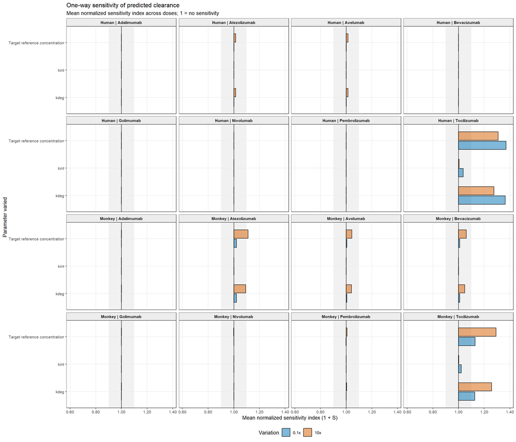

One-way sensitivity of predicted clearance.

```r
plot_data <- sa_mean_table |>
  mutate(
    Parameter = factor(
      .data$Parameter,
      levels = rev(names(SA_PARAMETER_PATHS))
    ),
    Variation = factor(
      .data$Variation_factor,
      levels = SA_FACTORS,
      labels = paste0(SA_FACTORS, "x")
    ),
    Panel = paste(.data$Species, .data$Molecule, sep = " | ")
  )

maximum_deviation <- max(
  abs(plot_data$Mean_normalized_sensitivity_coefficient),
  na.rm = TRUE
)
if (!is.finite(maximum_deviation) || maximum_deviation == 0) {
  maximum_deviation <- 0.1
}

sensitivity_plot <- ggplot(
  plot_data,
  aes(
    x = .data$Mean_normalized_sensitivity_coefficient,
    y = .data$Parameter,
    fill = .data$Variation
  )
) +
  annotate(
    "rect",
    xmin = -0.1,
    xmax = 0.1,
    ymin = -Inf,
    ymax = Inf,
    fill = "grey92",
    alpha = 0.7
  ) +
  geom_vline(xintercept = 0, colour = "grey35", linewidth = 0.55) +
  geom_col(
    position = position_dodge2(width = 0.8, preserve = "single"),
    width = 0.68
  ) +
  facet_wrap(~ Panel, ncol = 4) +
  scale_fill_manual(values = c("0.1x" = "#0072B2", "10x" = "#D55E00")) +
  scale_x_continuous(
    limits = c(-1, 1) * maximum_deviation * 1.05,
    labels = function(x) scales::label_number(accuracy = 0.01)(x + 1)
  ) +
  labs(
    title = "One-way sensitivity of predicted clearance",
    subtitle =
      "Mean normalized sensitivity index across doses; 1 = no sensitivity",
    x = "Mean normalized sensitivity index (1 + S)",
    y = "Parameter varied",
    fill = "Variation"
  ) +
  theme_bw(base_size = 10) +
  theme(
    strip.background = element_rect(fill = "grey93"),
    strip.text = element_text(face = "bold", size = 8),
    legend.position = "bottom",
    panel.grid.minor = element_blank()
  )

sensitivity_plot
```

# 7. Present the complete sensitivity record in this HTML

The dose-level table preserves every varied run and its comparison with the unvaried reference. The mean table is the source for the figure. Settings and software versions are included so the calculation can be reconstructed without a companion workbook.

## Raw varied-run clearances

```r
sa_results |>
  mutate(across(where(is.numeric), ~ round(.x, 5))) |>
  knitr::kable(
    caption = "Raw clearance results from all one-way perturbation runs",
    row.names = FALSE
  )
```

Raw clearance results from all one-way perturbation runs

| Scenario | Molecule | Species | Dose_mg_kg | Parameter | Variation_factor | Parameter_value | Parameter_unit | Varied_CL_L_day_kg |
| --- | --- | --- | --- | --- | --- | --- | --- | --- |
| Tocilizumab_Human_8_mpk | Tocilizumab | Human | 8.0 | Target reference concentration | 0.1 | 0.00010 | B5mol/l | 0.00423 |
| Tocilizumab_Human_8_mpk | Tocilizumab | Human | 8.0 | Target reference concentration | 10.0 | 0.01000 | B5mol/l | 0.02025 |
| Tocilizumab_Human_8_mpk | Tocilizumab | Human | 8.0 | kdeg | 0.1 | 0.00047 | 1/min | 0.00429 |
| Tocilizumab_Human_8_mpk | Tocilizumab | Human | 8.0 | kdeg | 10.0 | 0.04667 | 1/min | 0.01877 |
| Tocilizumab_Human_8_mpk | Tocilizumab | Human | 8.0 | kint | 0.1 | 0.00047 | 1/min | 0.00910 |
| Tocilizumab_Human_8_mpk | Tocilizumab | Human | 8.0 | kint | 10.0 | 0.04667 | 1/min | 0.01006 |
| Nivolumab_Human_1_mpk | Nivolumab | Human | 1.0 | Target reference concentration | 0.1 | 0.00001 | B5mol/l | 0.00335 |
| Nivolumab_Human_1_mpk | Nivolumab | Human | 1.0 | Target reference concentration | 10.0 | 0.00071 | B5mol/l | 0.00335 |
| Nivolumab_Human_1_mpk | Nivolumab | Human | 1.0 | kdeg | 0.1 | 0.00004 | 1/min | 0.00335 |
| Nivolumab_Human_1_mpk | Nivolumab | Human | 1.0 | kdeg | 10.0 | 0.00450 | 1/min | 0.00335 |
| Nivolumab_Human_1_mpk | Nivolumab | Human | 1.0 | kint | 0.1 | 0.00004 | 1/min | 0.00335 |
| Nivolumab_Human_1_mpk | Nivolumab | Human | 1.0 | kint | 10.0 | 0.00450 | 1/min | 0.00335 |
| Nivolumab_Human_3_mpk | Nivolumab | Human | 3.0 | Target reference concentration | 0.1 | 0.00001 | B5mol/l | 0.00336 |
| Nivolumab_Human_3_mpk | Nivolumab | Human | 3.0 | Target reference concentration | 10.0 | 0.00071 | B5mol/l | 0.00336 |
| Nivolumab_Human_3_mpk | Nivolumab | Human | 3.0 | kdeg | 0.1 | 0.00004 | 1/min | 0.00336 |
| Nivolumab_Human_3_mpk | Nivolumab | Human | 3.0 | kdeg | 10.0 | 0.00450 | 1/min | 0.00336 |
| Nivolumab_Human_3_mpk | Nivolumab | Human | 3.0 | kint | 0.1 | 0.00004 | 1/min | 0.00336 |
| Nivolumab_Human_3_mpk | Nivolumab | Human | 3.0 | kint | 10.0 | 0.00450 | 1/min | 0.00336 |
| Nivolumab_Human_4_mpk | Nivolumab | Human | 4.0 | Target reference concentration | 0.1 | 0.00001 | B5mol/l | 0.00336 |
| Nivolumab_Human_4_mpk | Nivolumab | Human | 4.0 | Target reference concentration | 10.0 | 0.00071 | B5mol/l | 0.00336 |
| Nivolumab_Human_4_mpk | Nivolumab | Human | 4.0 | kdeg | 0.1 | 0.00004 | 1/min | 0.00336 |
| Nivolumab_Human_4_mpk | Nivolumab | Human | 4.0 | kdeg | 10.0 | 0.00450 | 1/min | 0.00336 |
| Nivolumab_Human_4_mpk | Nivolumab | Human | 4.0 | kint | 0.1 | 0.00004 | 1/min | 0.00336 |
| Nivolumab_Human_4_mpk | Nivolumab | Human | 4.0 | kint | 10.0 | 0.00450 | 1/min | 0.00336 |
| Nivolumab_Human_6_mpk | Nivolumab | Human | 6.0 | Target reference concentration | 0.1 | 0.00001 | B5mol/l | 0.00337 |
| Nivolumab_Human_6_mpk | Nivolumab | Human | 6.0 | Target reference concentration | 10.0 | 0.00071 | B5mol/l | 0.00337 |
| Nivolumab_Human_6_mpk | Nivolumab | Human | 6.0 | kdeg | 0.1 | 0.00004 | 1/min | 0.00337 |
| Nivolumab_Human_6_mpk | Nivolumab | Human | 6.0 | kdeg | 10.0 | 0.00450 | 1/min | 0.00337 |
| Nivolumab_Human_6_mpk | Nivolumab | Human | 6.0 | kint | 0.1 | 0.00004 | 1/min | 0.00337 |
| Nivolumab_Human_6_mpk | Nivolumab | Human | 6.0 | kint | 10.0 | 0.00450 | 1/min | 0.00337 |

[output cut: 234 more lines]

## Complete dose-level sensitivity table

```r
sa_change_table |>
  mutate(across(where(is.numeric), ~ round(.x, 5))) |>
  knitr::kable(
    caption = "Dose-level clearance changes and normalized sensitivity",
    row.names = FALSE
  )
```

Dose-level clearance changes and normalized sensitivity

| Scenario | Molecule | Species | Dose_mg_kg | Parameter | Variation_factor | Parameter_value | Parameter_unit | Varied_CL_L_day_kg | Reference_CL_L_day_kg | Reference_individuals_n | Target | CL_percent_delta | Normalized_sensitivity_coefficient | Normalized_sensitivity_index |
| --- | --- | --- | --- | --- | --- | --- | --- | --- | --- | --- | --- | --- | --- | --- |
| Tocilizumab_Human_8_mpk | Tocilizumab | Human | 8.0 | Target reference concentration | 0.1 | 0.00010 | B5mol/l | 0.00423 | 0.00992 | 1 | IL-6R | -57.38678 | 0.37046 | 1.37046 |
| Tocilizumab_Human_8_mpk | Tocilizumab | Human | 8.0 | Target reference concentration | 10.0 | 0.01000 | B5mol/l | 0.02025 | 0.00992 | 1 | IL-6R | 103.99750 | 0.30962 | 1.30962 |
| Tocilizumab_Human_8_mpk | Tocilizumab | Human | 8.0 | kdeg | 0.1 | 0.00047 | 1/min | 0.00429 | 0.00992 | 1 | IL-6R | -56.81040 | 0.36462 | 1.36462 |
| Tocilizumab_Human_8_mpk | Tocilizumab | Human | 8.0 | kdeg | 10.0 | 0.04667 | 1/min | 0.01877 | 0.00992 | 1 | IL-6R | 89.07325 | 0.27663 | 1.27663 |
| Tocilizumab_Human_8_mpk | Tocilizumab | Human | 8.0 | kint | 0.1 | 0.00047 | 1/min | 0.00910 | 0.00992 | 1 | IL-6R | -8.26548 | 0.03747 | 1.03747 |
| Tocilizumab_Human_8_mpk | Tocilizumab | Human | 8.0 | kint | 10.0 | 0.04667 | 1/min | 0.01006 | 0.00992 | 1 | IL-6R | 1.31670 | 0.00568 | 1.00568 |
| Nivolumab_Human_1_mpk | Nivolumab | Human | 1.0 | Target reference concentration | 0.1 | 0.00001 | B5mol/l | 0.00335 | 0.00335 | 1 | PD-1 | 0.00013 | 0.00000 | 1.00000 |
| Nivolumab_Human_1_mpk | Nivolumab | Human | 1.0 | Target reference concentration | 10.0 | 0.00071 | B5mol/l | 0.00335 | 0.00335 | 1 | PD-1 | 0.00013 | 0.00000 | 1.00000 |
| Nivolumab_Human_1_mpk | Nivolumab | Human | 1.0 | kdeg | 0.1 | 0.00004 | 1/min | 0.00335 | 0.00335 | 1 | PD-1 | 0.00013 | 0.00000 | 1.00000 |
| Nivolumab_Human_1_mpk | Nivolumab | Human | 1.0 | kdeg | 10.0 | 0.00450 | 1/min | 0.00335 | 0.00335 | 1 | PD-1 | 0.00013 | 0.00000 | 1.00000 |
| Nivolumab_Human_1_mpk | Nivolumab | Human | 1.0 | kint | 0.1 | 0.00004 | 1/min | 0.00335 | 0.00335 | 1 | PD-1 | 0.00013 | 0.00000 | 1.00000 |
| Nivolumab_Human_1_mpk | Nivolumab | Human | 1.0 | kint | 10.0 | 0.00450 | 1/min | 0.00335 | 0.00335 | 1 | PD-1 | 0.00013 | 0.00000 | 1.00000 |
| Nivolumab_Human_3_mpk | Nivolumab | Human | 3.0 | Target reference concentration | 0.1 | 0.00001 | B5mol/l | 0.00336 | 0.00336 | 1 | PD-1 | -0.00005 | 0.00000 | 1.00000 |
| Nivolumab_Human_3_mpk | Nivolumab | Human | 3.0 | Target reference concentration | 10.0 | 0.00071 | B5mol/l | 0.00336 | 0.00336 | 1 | PD-1 | -0.00005 | 0.00000 | 1.00000 |
| Nivolumab_Human_3_mpk | Nivolumab | Human | 3.0 | kdeg | 0.1 | 0.00004 | 1/min | 0.00336 | 0.00336 | 1 | PD-1 | -0.00005 | 0.00000 | 1.00000 |
| Nivolumab_Human_3_mpk | Nivolumab | Human | 3.0 | kdeg | 10.0 | 0.00450 | 1/min | 0.00336 | 0.00336 | 1 | PD-1 | -0.00005 | 0.00000 | 1.00000 |
| Nivolumab_Human_3_mpk | Nivolumab | Human | 3.0 | kint | 0.1 | 0.00004 | 1/min | 0.00336 | 0.00336 | 1 | PD-1 | -0.00005 | 0.00000 | 1.00000 |
| Nivolumab_Human_3_mpk | Nivolumab | Human | 3.0 | kint | 10.0 | 0.00450 | 1/min | 0.00336 | 0.00336 | 1 | PD-1 | -0.00005 | 0.00000 | 1.00000 |
| Nivolumab_Human_4_mpk | Nivolumab | Human | 4.0 | Target reference concentration | 0.1 | 0.00001 | B5mol/l | 0.00336 | 0.00336 | 1 | PD-1 | -0.00016 | 0.00000 | 1.00000 |
| Nivolumab_Human_4_mpk | Nivolumab | Human | 4.0 | Target reference concentration | 10.0 | 0.00071 | B5mol/l | 0.00336 | 0.00336 | 1 | PD-1 | -0.00016 | 0.00000 | 1.00000 |
| Nivolumab_Human_4_mpk | Nivolumab | Human | 4.0 | kdeg | 0.1 | 0.00004 | 1/min | 0.00336 | 0.00336 | 1 | PD-1 | -0.00016 | 0.00000 | 1.00000 |
| Nivolumab_Human_4_mpk | Nivolumab | Human | 4.0 | kdeg | 10.0 | 0.00450 | 1/min | 0.00336 | 0.00336 | 1 | PD-1 | -0.00016 | 0.00000 | 1.00000 |
| Nivolumab_Human_4_mpk | Nivolumab | Human | 4.0 | kint | 0.1 | 0.00004 | 1/min | 0.00336 | 0.00336 | 1 | PD-1 | -0.00016 | 0.00000 | 1.00000 |
| Nivolumab_Human_4_mpk | Nivolumab | Human | 4.0 | kint | 10.0 | 0.00450 | 1/min | 0.00336 | 0.00336 | 1 | PD-1 | -0.00016 | 0.00000 | 1.00000 |
| Nivolumab_Human_6_mpk | Nivolumab | Human | 6.0 | Target reference concentration | 0.1 | 0.00001 | B5mol/l | 0.00337 | 0.00337 | 1 | PD-1 | 0.00019 | 0.00000 | 1.00000 |
| Nivolumab_Human_6_mpk | Nivolumab | Human | 6.0 | Target reference concentration | 10.0 | 0.00071 | B5mol/l | 0.00337 | 0.00337 | 1 | PD-1 | 0.00019 | 0.00000 | 1.00000 |
| Nivolumab_Human_6_mpk | Nivolumab | Human | 6.0 | kdeg | 0.1 | 0.00004 | 1/min | 0.00337 | 0.00337 | 1 | PD-1 | 0.00019 | 0.00000 | 1.00000 |
| Nivolumab_Human_6_mpk | Nivolumab | Human | 6.0 | kdeg | 10.0 | 0.00450 | 1/min | 0.00337 | 0.00337 | 1 | PD-1 | 0.00019 | 0.00000 | 1.00000 |
| Nivolumab_Human_6_mpk | Nivolumab | Human | 6.0 | kint | 0.1 | 0.00004 | 1/min | 0.00337 | 0.00337 | 1 | PD-1 | 0.00019 | 0.00000 | 1.00000 |
| Nivolumab_Human_6_mpk | Nivolumab | Human | 6.0 | kint | 10.0 | 0.00450 | 1/min | 0.00337 | 0.00337 | 1 | PD-1 | 0.00019 | 0.00000 | 1.00000 |

[output cut: 234 more lines]

## Mean sensitivity across doses

```r
sa_mean_table |>
  mutate(across(where(is.numeric), ~ round(.x, 5))) |>
  knitr::kable(
    caption = "Mean one-way sensitivity results across doses",
    row.names = FALSE
  )
```

Mean one-way sensitivity results across doses

| Species | Target | Molecule | Parameter | Variation_factor | Mean_CL_percent_delta | Mean_normalized_sensitivity_coefficient | Doses_averaged_n | Mean_normalized_sensitivity_index |
| --- | --- | --- | --- | --- | --- | --- | --- | --- |
| Human | IL-6R | Tocilizumab | Target reference concentration | 0.1 | -57.38678 | 0.37046 | 1 | 1.37046 |
| Human | IL-6R | Tocilizumab | Target reference concentration | 10.0 | 103.99750 | 0.30962 | 1 | 1.30962 |
| Human | IL-6R | Tocilizumab | kdeg | 0.1 | -56.81040 | 0.36462 | 1 | 1.36462 |
| Human | IL-6R | Tocilizumab | kdeg | 10.0 | 89.07325 | 0.27663 | 1 | 1.27663 |
| Human | IL-6R | Tocilizumab | kint | 0.1 | -8.26548 | 0.03747 | 1 | 1.03747 |
| Human | IL-6R | Tocilizumab | kint | 10.0 | 1.31670 | 0.00568 | 1 | 1.00568 |
| Human | PD-1 | Nivolumab | Target reference concentration | 0.1 | 0.00002 | 0.00000 | 6 | 1.00000 |
| Human | PD-1 | Nivolumab | Target reference concentration | 10.0 | 0.00002 | 0.00000 | 6 | 1.00000 |
| Human | PD-1 | Nivolumab | kdeg | 0.1 | 0.00002 | 0.00000 | 6 | 1.00000 |
| Human | PD-1 | Nivolumab | kdeg | 10.0 | 0.00002 | 0.00000 | 6 | 1.00000 |
| Human | PD-1 | Nivolumab | kint | 0.1 | 0.00002 | 0.00000 | 6 | 1.00000 |
| Human | PD-1 | Nivolumab | kint | 10.0 | 0.00002 | 0.00000 | 6 | 1.00000 |
| Human | PD-1 | Pembrolizumab | Target reference concentration | 0.1 | -0.00085 | 0.00000 | 2 | 1.00000 |
| Human | PD-1 | Pembrolizumab | Target reference concentration | 10.0 | -0.00085 | 0.00000 | 2 | 1.00000 |
| Human | PD-1 | Pembrolizumab | kdeg | 0.1 | -0.00085 | 0.00000 | 2 | 1.00000 |
| Human | PD-1 | Pembrolizumab | kdeg | 10.0 | -0.00085 | 0.00000 | 2 | 1.00000 |
| Human | PD-1 | Pembrolizumab | kint | 0.1 | -0.00085 | 0.00000 | 2 | 1.00000 |
| Human | PD-1 | Pembrolizumab | kint | 10.0 | -0.00085 | 0.00000 | 2 | 1.00000 |
| Human | PD-L1 | Atezolizumab | Target reference concentration | 0.1 | -0.35964 | 0.00157 | 5 | 1.00157 |
| Human | PD-L1 | Atezolizumab | Target reference concentration | 10.0 | 3.70977 | 0.01545 | 5 | 1.01545 |
| Human | PD-L1 | Atezolizumab | kdeg | 0.1 | -0.35474 | 0.00155 | 5 | 1.00155 |
| Human | PD-L1 | Atezolizumab | kdeg | 10.0 | 3.61927 | 0.01509 | 5 | 1.01509 |
| Human | PD-L1 | Atezolizumab | kint | 0.1 | -0.00126 | 0.00001 | 5 | 1.00001 |
| Human | PD-L1 | Atezolizumab | kint | 10.0 | 0.00026 | 0.00000 | 5 | 1.00000 |
| Human | PD-L1 | Avelumab | Target reference concentration | 0.1 | -0.34944 | 0.00152 | 4 | 1.00152 |
| Human | PD-L1 | Avelumab | Target reference concentration | 10.0 | 3.58495 | 0.01503 | 4 | 1.01503 |
| Human | PD-L1 | Avelumab | kdeg | 0.1 | -0.34315 | 0.00150 | 4 | 1.00150 |
| Human | PD-L1 | Avelumab | kdeg | 10.0 | 3.48848 | 0.01464 | 4 | 1.01464 |
| Human | PD-L1 | Avelumab | kint | 0.1 | -0.00058 | 0.00000 | 4 | 1.00000 |
| Human | PD-L1 | Avelumab | kint | 10.0 | 0.00013 | 0.00000 | 4 | 1.00000 |

[output cut: 66 more lines]

## Analysis settings and package versions

```r
analysis_settings <- bind_rows(
  tibble(Setting = "Selected baseline run", Value = basename(results_folder)),
  tibble(Setting = "AUC horizon (hours)", Value = as.character(AUC_END_H)),
  tibble(
    Setting = "Variation factors",
    Value = paste(SA_FACTORS, collapse = ", ")
  ),
  tibble(
    Setting = paste0("Parameter path: ", names(SA_PARAMETER_PATHS)),
    Value = unname(SA_PARAMETER_PATHS)
  ),
  transmute(
    package_versions,
    Setting = paste0("R package: ", .data$Package),
    Value = .data$Installed
  ) |>
    select(.data$Setting, .data$Value)
)

analysis_settings |>
  knitr::kable(caption = "Sensitivity-analysis settings")
```

Sensitivity-analysis settings

| Setting | Value |
| --- | --- |
| Selected baseline run | 2026-09-27 18-41 |
| AUC horizon (hours) | 672 |
| Variation factors | 0.1, 10 |
| Parameter path: Target reference concentration | Target\|Reference concentration |
| Parameter path: kint | Complex Internalization\|kint |
| Parameter path: kdeg | Target degradation\|kdeg |
| R package: esqlabsR | 5.7.0 |
| R package: ospsuite | 12.4.3 |
| R package: dplyr | 1.2.1 |
| R package: tidyr | 1.3.2 |
| R package: purrr | 1.2.2 |
| R package: tibble | 3.3.1 |
| R package: ggplot2 | 4.0.3 |
| R package: scales | 1.4.0 |
| R package: data.table | 1.18.4 |
| R package: openxlsx | 4.2.9 |
| R package: knitr | 1.51 |

# Interpretation checklist

1. Confirm that each scenario has six varied runs.
2. Use the dose-level results before relying on the across-dose mean; averaging can conceal dose-dependent target-mediated behavior.
3. Interpret an index near 1 as weak local sensitivity over the tested change.
4. Inspect the direction as well as the magnitude. The 0.1-fold and 10-fold perturbations need not be symmetric in a nonlinear PBPK/TMDD model.
5. Treat this result as a model-behavior diagnostic, not as evidence that the biological parameters truly span 0.1 to 10 times their literature values.